# Santander Customer Transaction Prediction

Team 4: Driss Baraket, Yanjie Long, Garrett deFisser, Emma Harrison

4/19/2021

### Background and Overview

#### Santander Bank

Santander Bank is a wholly owned subsidiary of the Spanish Santander Group. As part of its operation mission, Santander offers services to help people and businesses prosper. They work tirelessly to help their customers understand their financial health and identify which products and services might help them achieve their monetary goals.

In this presentation, our group will develop several models in the effort to understand specific customer behavior. We will be using the data set “Santander Customer Transaction Prediction” to help classify a target variable that predicts the answer to questions such as: is the customer satisfied with a product or service? Will a customer buy a particular product? Or can a customer pay this loan?

[figure not shown]

#### Kaggle Competition

Kaggle is a crowd-sourced platform with the goal to attract, nurture, train and challenge data scientists from all around the world to solve data science, machine learning and predictive analytics problems.

Interesting Fact: Do you know that most data scientists are only theorists and rarely get a chance to practice before being employed in the real-world? Kaggle solves this problem by giving data science enthusiasts a platform to interact and compete in solving real-life problems.

The experience you get on Kaggle is invaluable in preparing you to understand what goes into finding feasible solutions for big data

#### Dataset

We will be using the “Santander Customer Transaction Prediction” dataset:

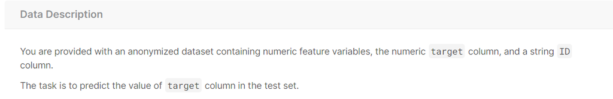

**1.** The dataset is directly provided by the Santander the Bank with a real-life structure.

**2.** The features have been renamed for security and discretionary purposes. File size is 1.01 GB.

**3.** The data contains 201 features, 1 target value and 200,000 observations.

### Data Preparation

```r
### Laoding in the main traing set: train
SantanderDF <- read.csv("train.csv", stringsAsFactors=T, header=T)
sum(is.na(SantanderDF)) #0
```

```
## [1] 0
```

```r
SantanderDF<-na.omit(SantanderDF)
SantanderDF <- SantanderDF[, -1]
target <- as.numeric(factor(SantanderDF$target))


### DataFrame Partition for Logistic
set.seed(5082)
train.rows <- sample(nrow(SantanderDF), nrow(SantanderDF) * .75)
DF.train <- SantanderDF[train.rows, ]
DF.test <- SantanderDF[-train.rows, ]

### Matrix Partition for Lasso and Xgboost
x=model.matrix(target~.,SantanderDF)[,-1]
y=SantanderDF$target

set.seed(5082)
train = sample(1:nrow(x), nrow(x)*3/4)
test = (-train)
x.train = x[train,]
x.test = x[test, ]
y.train = y[train]
y.test =y[test]
```

### Lasso

**Lasso** is a type of regression analysis that performs both variable selection and regularization to enhance prediction accuracy. It is a powerful method that performs two main tasks: regularization and feature selection.

During the feature selection process the variables that still have a non-zero coefficient after the shrinking process are selected to be part of the model.

The goal of this process is to minimize the prediction error.

There are many advantages in using lasso:

**1.** Very good prediction accuracy

**2.** Easily interpreted model

**3.** Overfitting is reduced

There are also some disadvantages to lasso:

**1.** The model isn’t very stable, so the selected features might change each time it is run

**2.** The model selection result is not intuitive to interpret

**3.** Doesn’t perform well with highly correlated features

```r
library(glmnet)
# Create a grid of 50 lambda values to tune
grid = 10^seq(10,-2,length=50)

set.seed(5082)
# Train a Lasso model using the training dataset and the lambda grid created above
mod.lasso <- glmnet(x.train,
                    y.train,
                    alpha=1,
                    lambda=grid,
                    standardize = TRUE,
                    family="binomial",
                    type.measure = "mse")

# Evaluate training model performance using cross-validation
cv.out.class <- cv.glmnet(x.train,
                          y.train,
                          alpha=1,
                          lambda=grid,
                          nfolds = 10,
                          family="binomial")

# Display the best cross-validated lambda value:
(bestlam <- cv.out.class$lambda.min)
```

```
## [1] 0.01
```

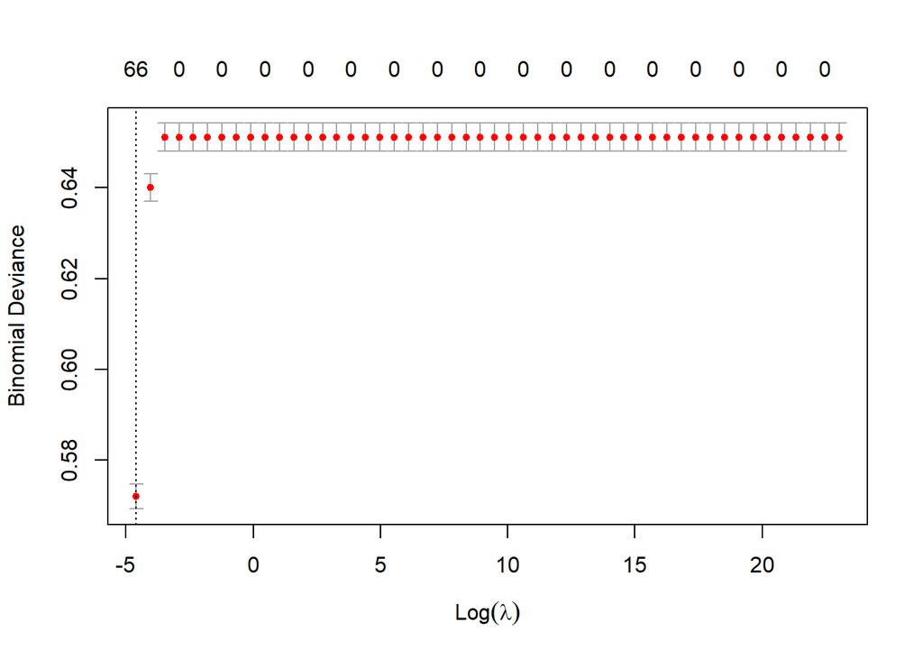

```r
#cross validation can also be used to select lambda.
plot(cv.out.class)
```

```r
# Using the best lambda and the trained model,
lasso.pred.class <- predict(mod.lasso,
                            s=bestlam,
                            newx=x.test,
                            type="class")

# Display the resulting confusion matrix.
table(y.test, lasso.pred.class)
```

```
##       lasso.pred.class
## y.test     0
##      0 44935
##      1  5065
```

```r
mean(lasso.pred.class != y.test)
```

```
## [1] 0.1013
```

```r
# Display the coefficients of the model associated with the best lambda.
coef.lasso=predict(cv.out.class,type="coefficients",s=bestlam)[1:200,]
coef.lasso[coef.lasso ==0]
```

```
##   var_3   var_4   var_5   var_7   var_8  var_10  var_11  var_14  var_15  var_16
##       0       0       0       0       0       0       0       0       0       0
##  var_17  var_19  var_20  var_23  var_24  var_25  var_27  var_28  var_29  var_30
##       0       0       0       0       0       0       0       0       0       0
##  var_31  var_32  var_37  var_38  var_39  var_41  var_42  var_43  var_45  var_46
##       0       0       0       0       0       0       0       0       0       0
##  var_47  var_48  var_49  var_50  var_51  var_52  var_54  var_55  var_57  var_58
##       0       0       0       0       0       0       0       0       0       0
##  var_59  var_60  var_61  var_62  var_63  var_64  var_65  var_66  var_68  var_69
##       0       0       0       0       0       0       0       0       0       0
##  var_70  var_71  var_72  var_73  var_74  var_77  var_79  var_82  var_83  var_84
##       0       0       0       0       0       0       0       0       0       0
##  var_85  var_88  var_90  var_96  var_97  var_98 var_100 var_101 var_102 var_103
##       0       0       0       0       0       0       0       0       0       0
## var_104 var_105 var_106 var_111 var_112 var_113 var_114 var_116 var_117 var_119
##       0       0       0       0       0       0       0       0       0       0
## var_120 var_124 var_125 var_126 var_128 var_129 var_130 var_131 var_132 var_134
##       0       0       0       0       0       0       0       0       0       0
## var_135 var_136 var_137 var_138 var_140 var_141 var_142 var_143 var_144 var_145
##       0       0       0       0       0       0       0       0       0       0
## var_150 var_151 var_152 var_153 var_156 var_157 var_158 var_159 var_160 var_161
##       0       0       0       0       0       0       0       0       0       0
## var_162 var_163 var_167 var_168 var_171 var_175 var_176 var_177 var_178 var_180
##       0       0       0       0       0       0       0       0       0       0
## var_181 var_182 var_183 var_185 var_186 var_187 var_188 var_189 var_193 var_194
##       0       0       0       0       0       0       0       0       0       0
## var_195 var_196 var_197
##       0       0       0
```

- Based on the lasso, model, we have to take out 133 features.

### Logistic Regression

Logistic Regression is a type of regression that is typically used for classification and it is simple to implement.

*Pros:*

**1.** Very efficient to train

**2.** Good accuracy for datasets that are linearly separable

**3.** Doesn’t overfit the data

*Cons:*

**1.** Can’t be used with non-linear data

**2.** Doesn’t work well with multi-collinearity

Logistic regression works well, but there are some problems with this model: **1.** Feature selection is not very efficient with 200 features

**2.** Assumptions check

```
  - Multicolinearity
  - Linearity
  - Heteroscadesticity
```

**3.** Methods used on Kaggle:

Generate correlation table, drop highly correlated columns that have a correlation larger than 0.95 https://www.kaggle.com/ashu11081992/basic-logistic-regression

- Ignored the problem:https://www.kaggle.com/nurzhann173/logistic-regression
- Both Problematic

```r
#Based on the features deleted by Lasso
Vars <- list(read.csv("VarsWithTarget.csv"))
x1.train <- DF.train[, c(1,unlist(Vars))]
x1.train$target = as.factor(x1.train$target)

x1.test <- DF.test[, c(1,unlist(Vars))]
x1.test$target = as.factor(x1.test$target)

x1.train[, -c(1)] <- scale(x1.train[, -c(1)])
x1.test[, -c(1)] <- scale(x1.test[, -c(1)])

x1.train = data.frame(x1.train)
x1.test = data.frame(x1.test)
```

```r
set.seed(5082)
model<-glm(target~ .-var_27-var_38-var_41-var_17-var_30-var_14-var_10-var_7-var_29, data=x1.train, family=binomial)
summary(model)
```

```
##
## Call:
## glm(formula = target ~ . - var_27 - var_38 - var_41 - var_17 -
##     var_30 - var_14 - var_10 - var_7 - var_29, family = binomial,
##     data = x1.train)
##
## Deviance Residuals:
##     Min       1Q   Median       3Q      Max
## -0.8804  -0.4926  -0.4362  -0.3795   2.6702
##
## Coefficients:
##              Estimate Std. Error  z value Pr(>|z|)
## (Intercept) -2.243704   0.008976 -249.959  < 2e-16 ***
## var_3        0.041319   0.008651    4.776 1.79e-06 ***
## var_4        0.029020   0.008653    3.354 0.000797 ***
## var_5        0.104358   0.008658   12.054  < 2e-16 ***
## var_8        0.065177   0.008681    7.508 6.01e-14 ***
## var_11       0.079289   0.008637    9.180  < 2e-16 ***
## var_15       0.060752   0.008645    7.028 2.10e-12 ***
## var_16       0.030271   0.008632    3.507 0.000454 ***
## var_19       0.035848   0.008638    4.150 3.32e-05 ***
## var_20      -0.069188   0.008670   -7.980 1.47e-15 ***
## var_23      -0.084156   0.008679   -9.697  < 2e-16 ***
## var_24       0.085095   0.008615    9.878  < 2e-16 ***
## var_25       0.049203   0.008618    5.709 1.14e-08 ***
## var_31      -0.086174   0.008684   -9.923  < 2e-16 ***
## var_32       0.102540   0.008663   11.836  < 2e-16 ***
## var_37       0.025145   0.008647    2.908 0.003639 **
## var_42      -0.020515   0.008639   -2.375 0.017558 *
## var_43      -0.104898   0.008656  -12.119  < 2e-16 ***
## var_45      -0.059734   0.008651   -6.905 5.03e-12 ***
## var_47       0.030116   0.008652    3.481 0.000500 ***
## var_48       0.102268   0.008655   11.815  < 2e-16 ***
## var_49       0.101018   0.008647   11.683  < 2e-16 ***
## var_50      -0.049960   0.008635   -5.786 7.22e-09 ***
## var_51       0.088883   0.008636   10.292  < 2e-16 ***
## var_54      -0.054541   0.008646   -6.308 2.82e-10 ***
## var_55       0.053869   0.008625    6.246 4.22e-10 ***
## ---
## Signif. codes:  0 '***' 0.001 '**' 0.01 '*' 0.05 '.' 0.1 ' ' 1
##
## (Dispersion parameter for binomial family taken to be 1)
##
##     Null deviance: 97670  on 149999  degrees of freedom
## Residual deviance: 96026  on 149974  degrees of freedom
## AIC: 96078
##
## Number of Fisher Scoring iterations: 5
```

```r
##calculations for training error and accuracy rate
probabilities_train <- predict(model, x1.train, type="response")
pred_train <-ifelse(probabilities_train>.5, "1", "0")

# The training accuracy and Error Rate:
mean(pred_train==x1.train$target)##training accuracy rate
```

```
## [1] 0.89978
```

```r
mean(pred_train!=x1.train$target)##training error rate
```

```
## [1] 0.10022
```

```r
table(pred_train, x1.train$target)##confusion matrix
```

```
##
## pred_train      0      1
##          0 134967  15033
```

```r
##calculations for testing error and accuracy rate
probabilities_test<-predict(model, x1.test, type="response")
pred_test<-ifelse(probabilities_test>.5, "1", "0")

# The testing accuracy and Error Rate:
mean(pred_test==x1.test$target) ###testing accuracy rate
```

```
## [1] 0.8987
```

```r
mean(pred_test!=x1.test$target) ###testing error rate
```

```
## [1] 0.1013
```

```r
table(pred_test, x1.test$target)##confusion matrix
```

```
##
## pred_test     0     1
##         0 44935  5065
```

### Xgboost

XGBoost (Extreme Gradient Boosting) is an optimized distributed gradient boosting library. Yes, it uses gradient boosting (GBM) framework at core. Yet, does better than GBM framework alone

*Let’s look at what makes it so good:*

**1.** Parallel Computing: It is enabled with parallel processing (using OpenMP); i.e., when you run xgboost, by default, it would use all the cores of your laptop/machine

**2.** Regularization: I believe this is the biggest advantage of xgboost. GBM has no provision for regularization. Regularization is a technique used to avoid overfitting in linear and tree-based models.

**3.** Enabled Cross Validation: In R, we usually use external packages such as caret and mlr to obtain CV results. But, xgboost is enabled with internal CV function (we’ll see below)

**4.** Missing Values: XGBoost is designed to handle missing values internally. The missing values are treated in such a manner that if there exists any trend in missing values, it is captured by the model

**5.** Flexibility: In addition to regression, classification, and ranking problems, it supports user-defined objective functions also. An objective function is used to measure the performance of the model given a certain set of parameters. Furthermore, it supports user defined evaluation metrics as well

**6.** Availability: Currently, it is available for programming languages such as R, Python, Java, Julia, and Scala

**7.** Save and Reload: XGBoost gives us a feature to save our data matrix and model and reload it later. Suppose, we have a large data set, we can simply save the model and use it in future instead of wasting time redoing the computation

**8.** Tree Pruning: Unlike GBM, where tree pruning stops once a negative loss is encountered, XGBoost grows the tree upto max_depth and then prune backward until the improvement in loss function is below a threshold

```r
library(MLmetrics)
library(xgboost)
library(pROC)
library(ROCR)
set.seed(5082)
# Cross validation model
xgboost1.Santander = xgb.cv(data = x.train, label= y.train, nrounds = 25, nthread = 2, nfold = 5, metrics = list("rmse","auc"), max_depth = 3, eta = 0.1, objective = "binary:logistic", verbose = F, prediction = T)

it = which.max(xgboost1.Santander$evaluation_log$test_auc_mean)
best.iter = xgboost1.Santander$evaluation_log$iter[it]

# Train an xgboost model
xgboost.Santander=xgboost(data=x.train, # X features have to be in matrix form
                          label= y.train, # Y is a vector
                          eta = 0.1, # learning rate
                          nthread = 3, # number of paralell threads
                          nround = best.iter, # number of rounds of predictions
                          print_every_n = 5,
                          objective = "binary:logistic", # regression (for classification, specify"binary:logistic")
                          n.trees=500, # number of trees
                          eval_metric = 'auc',
                          max.depth=4, # number of splits
                          verbose = T) # print training error
```

[output not shown]

```r
#The objective function binary:logistic returns output probabilities rather than actual target numbers

# Predict y hats using the xgboost model
yhat.boost=predict(xgboost.Santander,
                   newdata=x.test ,
                   n.trees=500)

#Getting the error rate
err <- mean(as.numeric(yhat.boost > 0.5) != y.test)
print(paste("val-error=", err))
```

```
## [1] "val-error= 0.10128"
```

```r
#Cutoff Value for classifcation
yhat.boost <- ifelse (yhat.boost > 0.5,1,0)

#Confusion Matrix for classifcation
table(yhat.boost, y.test)
```

```
##           y.test
## yhat.boost     0     1
##          0 44935  5064
##          1     0     1
```

```r
((44935 + 1)/ (44921 + 1 + 5064 + 0))
```

```
## [1] 0.8989717
```

```r
#0.8989717%

# Given that our goal is to identify disatisfaction or whether customers will not buy a particular product
# Let us treat "Disatisfaction = 0" as the positive event

# Compute and display the true positive rate (sensitivity or recall)
Sensitivity1 <- 44935 / (44935+0)
Sensitivity1      #1.0000
```

```
## [1] 1
```

```r
# Also, compute and display the precision rate
precision1 <- 44935 / (44935 +5064)
precision1      #0.898718
```

```
## [1] 0.898718
```

```r
# Next, use sensitivity and precision to compute F1 score

F1 = 2* (precision1*Sensitivity1)/(precision1+Sensitivity1)
F1   #0.9465181
```

```
## [1] 0.9466577
```

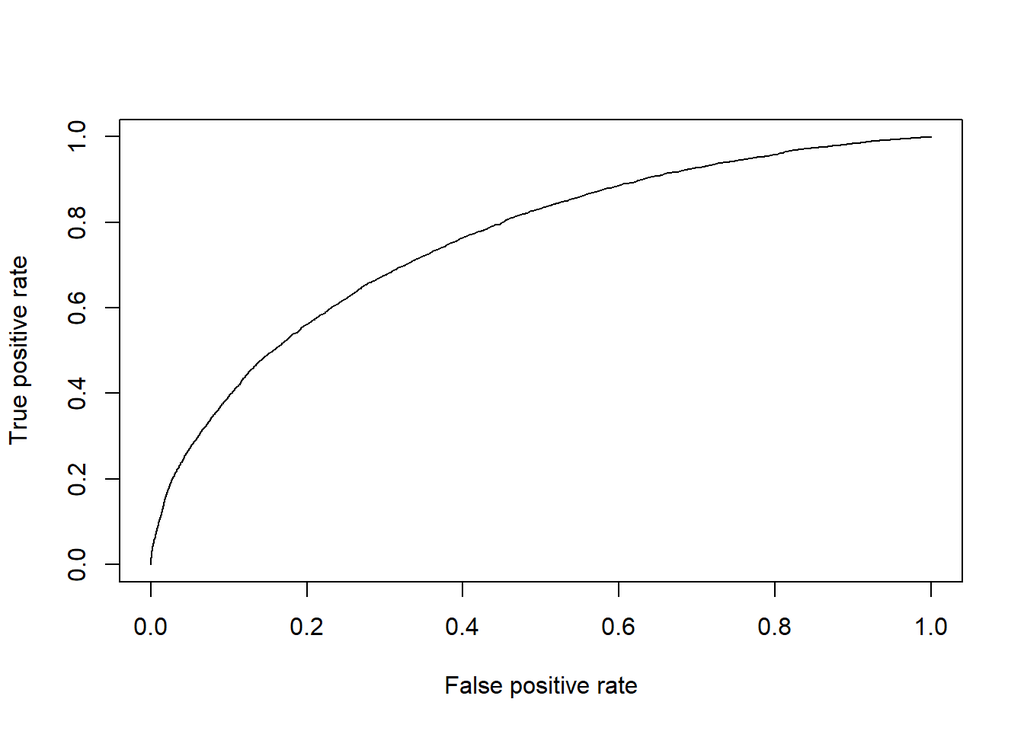

```r
# Create the ROC curve using true positive and false positive rates

# Use ROCR package to plot ROC Curve
xgb.pred <- prediction(yhat.boost, y.test,label.ordering = c("0","1"))
xgb.perf <- performance(xgb.pred, "tpr", "fpr")

#plot(roc(response = y.train,
#         predictor = xgboost1.Santander$pred,
#         levels=c(0, 1)),
#     main = "ROC CURVE",
#     xlim=c(1, 0), ylim=c(0, 1))

phat = predict(xgboost.Santander,x.test)
require(ROCR)
pred = prediction(phat,y.test)
perf = performance(pred,"tpr","fpr")
plot(perf)
```

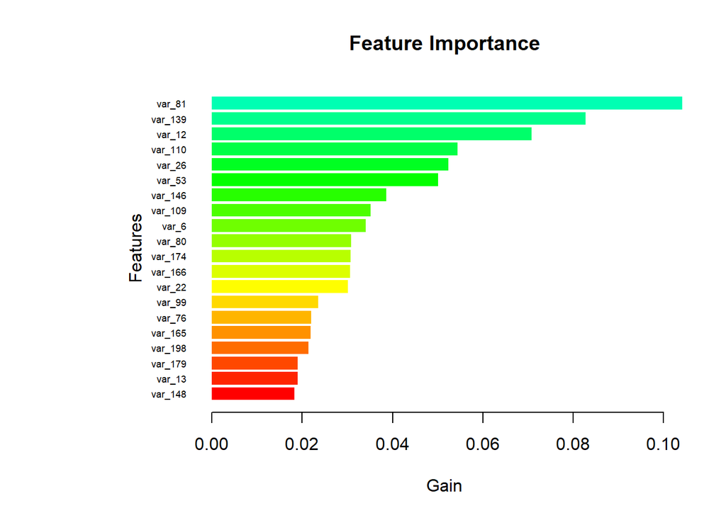

```r
#view variable importance plot
#the most important influencing factors on the predicted values
mat <- xgb.importance (feature_names = colnames(x.train),model = xgboost.Santander)
xgb.plot.importance (importance_matrix = mat[1:20],xlab = "Gain", ylab = 'Features',
                     main="Feature Importance",
                     col= rainbow(20, start = 0, end = .45))
```

*Comparisson to Public Notebook:*

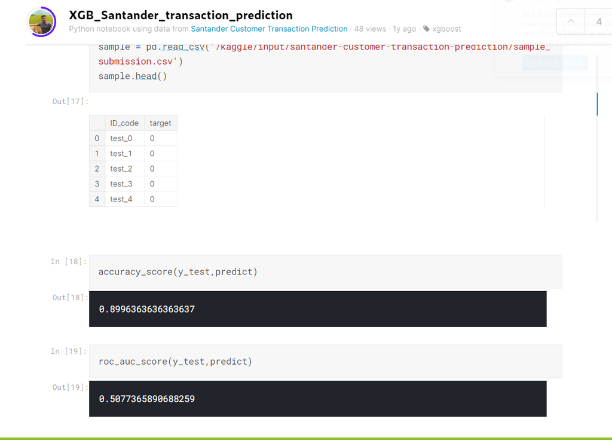

Also, we calculated the following ratios:

Recall(or sensitivity): for this competition, is by far a more important ratio since it is important to even indentify some customers who will not be purchassing certain product or services rather than leaving an interested customer out.  
Recall = 1.00000

Precision: is how sure you are of your true positives and if we want to cover all true negatives. In our model, false positives are intolerable, so this ratio is not as important as recall. Precision = 0.898718

ROC: Shows the performance of a classification model at all classification thresholds. Lowering the classification threshold classifies more items as “0”, thus increasing both False Positives and True Positives.

### Machine Learning Reproducibility Checklist

**1.** In our presentation, we explicitly described the three models (lasso, logistic, and XGBoost)

**2.** During logistic regression, because of the number of features used we had to do feature elimination to be able to satisfy the assumptions (linearity, multicollinearity, and heteroscadesticity) - The public notebooks that we found using logistic regression didn’t check assumptions appropriately. Without considering the assumptions, such as linearity and multicollinearity, the model could be problematic even with its high accuracy.

**3.** When trying to run an SVM model, we faced an issue with the sample size and space and were not able to create a working model. Having a range of costs and gamma in order to tune our model introduced even more complexity

**4.** All theoretical claims made were substantiated with code

*For all datasets used:*

**1.** Santander Customer Transaction Prediction included 202 features and 200,000 observations. The id was excluded from the features because it didn’t provide any relevant data and there were no NA’s

**2.** The data was split into train and test sets with the train set having 75% of the observations

**3.** To preprocess this data, we scaled and normalized our observations

**4.** https://www.kaggle.com/c/santander-customer-transaction-prediction/data?select=train.csv

*For all shared code:*

**1.** The Rmd provides specification of dependencies, training code, evaluation code, and pre-trained models

For all reported experimental results:

**1.** The range of hyper-parameters considered as well as the best hyper-parameters used were all discussed within the code

**2.** The number of parameters for training and evaluation runs are mentioned as well

**3.** The specific measure used to report results are accuracy, test error rates, area under the curve, and ROC

**4.** The description results were run for models when needed

**5.** The average runtime for each result varied between 5 and 15 minutes

**6.** The computing infrastructure used was RStudio and RMarkdown